# SWE Analysis

AnnaClaire Marley

03/07/2019

## Analyses:

- All three regions generally follow the same trends in SWE over time
- 2010 was a high SWE year
- Black Mesa and Carrizo are the most closely correlated

### Annual avereage SWE

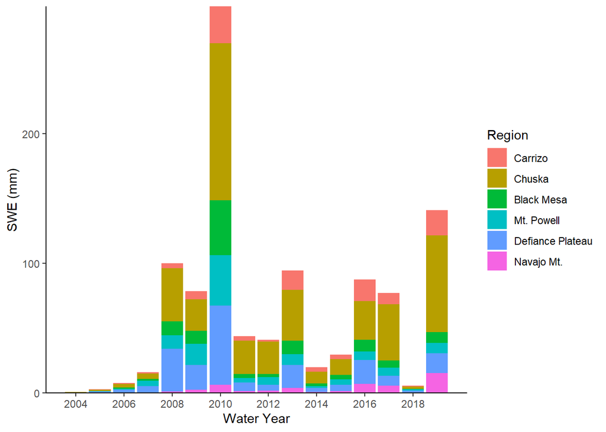

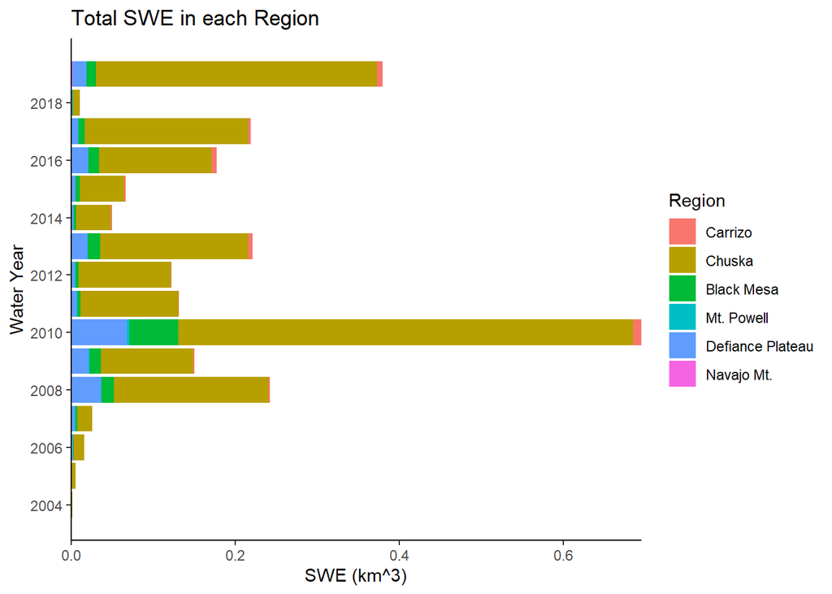

The annual average % contribution to the total annual average swe of all 6 mountain ranges:

- Chuska: 0.81
- Defiance Plateau 0.11
- Black Mesa 0.06
- Carrizo: 0.02
- Navajo Mt 0.0023
- Mt Powell 0.0049

## Daily SWE variability (November - April Water Year)

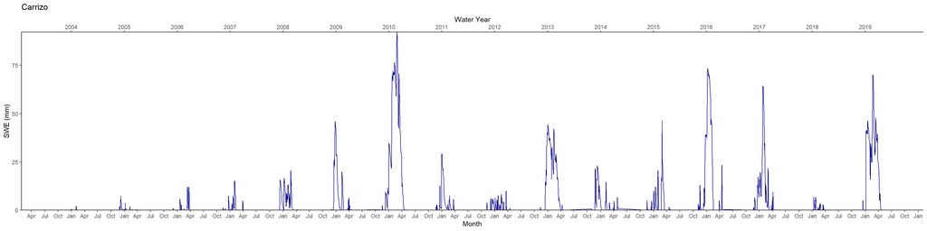

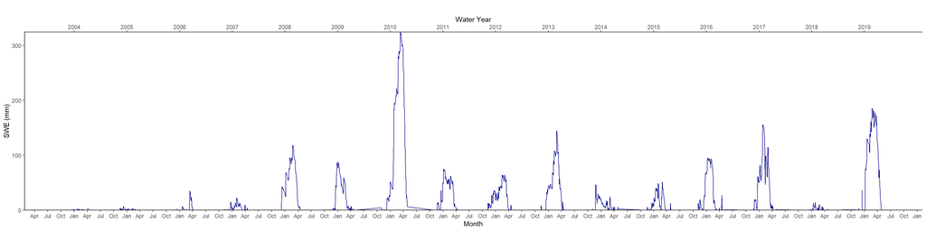

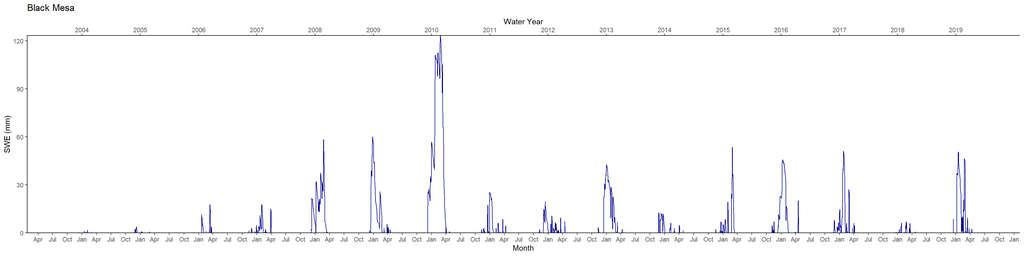

## Monthly Mean SWE variability (November - April Water Year)

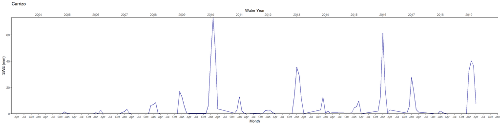

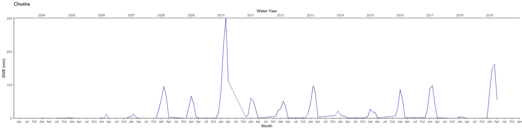

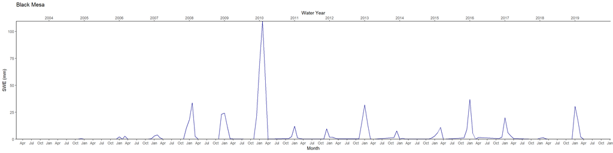

### Correlation matrix of all monthly mean swe

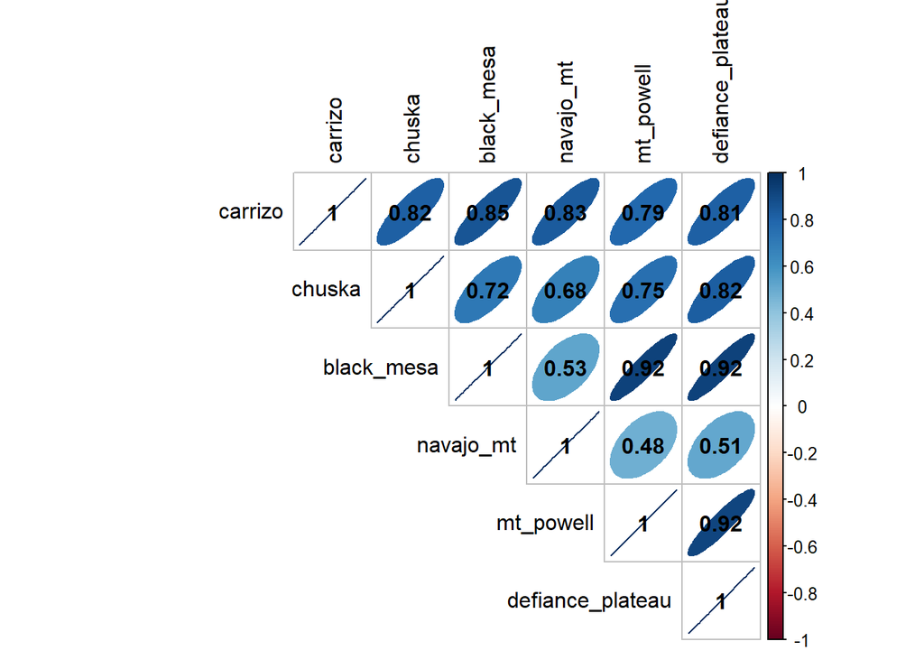

- Black Mesa to Mt. Powell, Black Mesa to Defiance Plateau and Defiance Plateau and Mt Powell all have the highest correlations between each other - Least correlated are Black Mesa and Navajo Mt, Navajo Mt and Mt Powell, Navajo Mt and Defiance Plateau

# Monthly Median

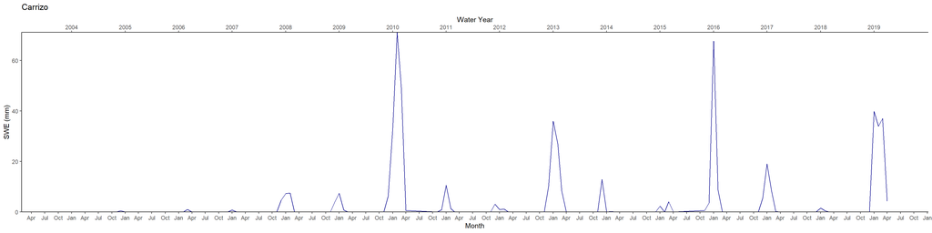

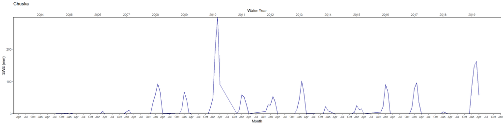

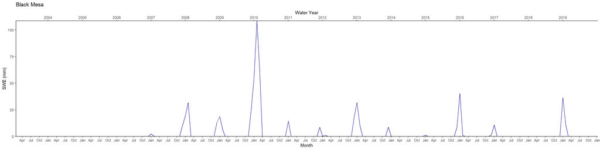

## Monthly Anomalies (November - April Water Year)

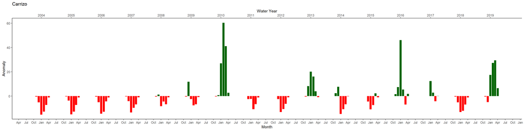

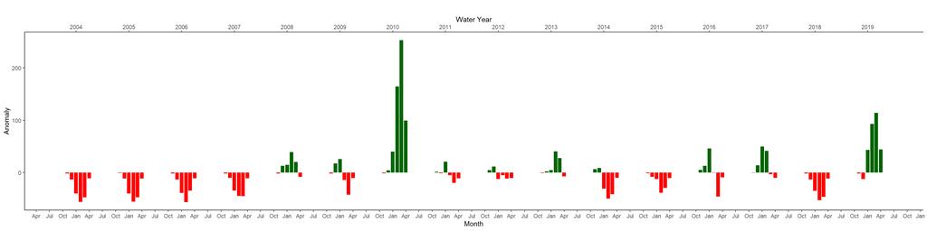

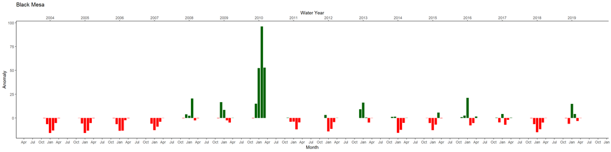

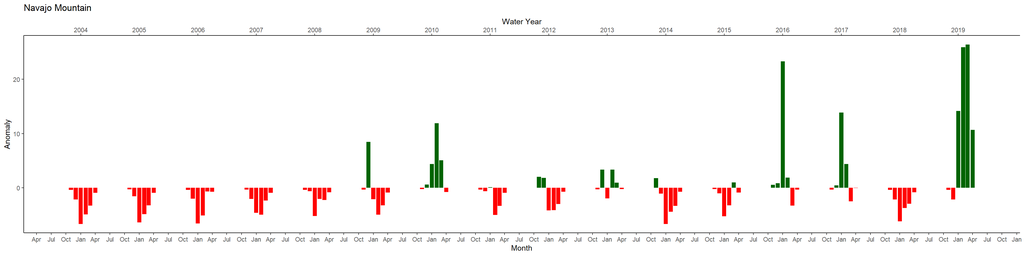

## Correlations Between locations

### Weekly mean correlation November - April

Pearson’s Correlation R squared:

- Chuska vs Black Mesa: 0.46
- Carrizo vs Chuska: 0.63
- Carrizo vs Black Mesa: 0.73

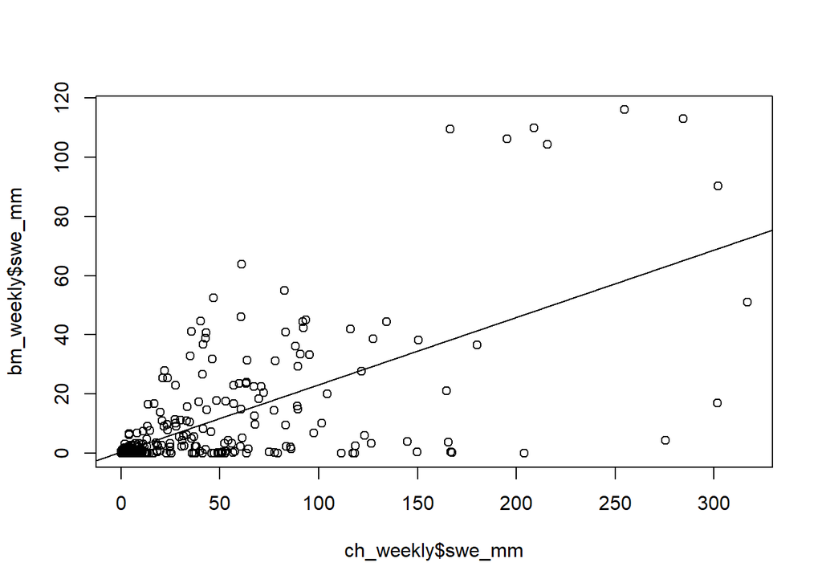

Chuska vs Black Mesa R squared: 0.4634808

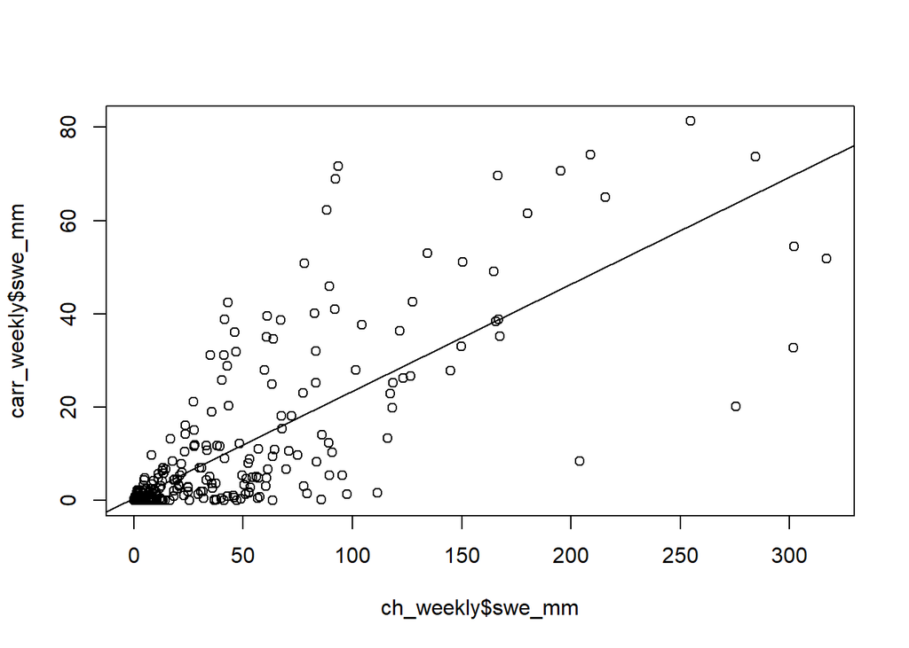

Chuska vs Carrizo R squared: 0.631619

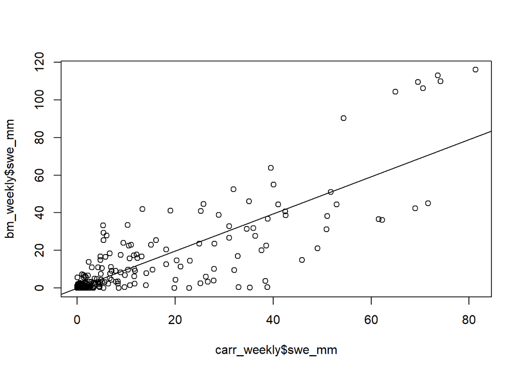

Black Mesa vs Carrizo R squared: 0.7250093

# November

# December

# January

# February

# March

# April

### November - April Averaged SWE values

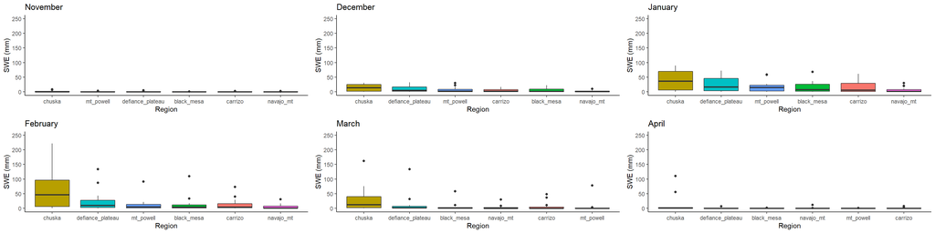

- Chuska and Defiance plateau frequently have the higest av swe values, navajo mt usually has the least.
- most everything is melted by april

## Total SWE for each region analyses

```r
all_swe_total <- read_csv("winter_wy/all_swe_total.csv")
# monthly mean totals for each region
```

### SWE compared to Suzanne’s SCA

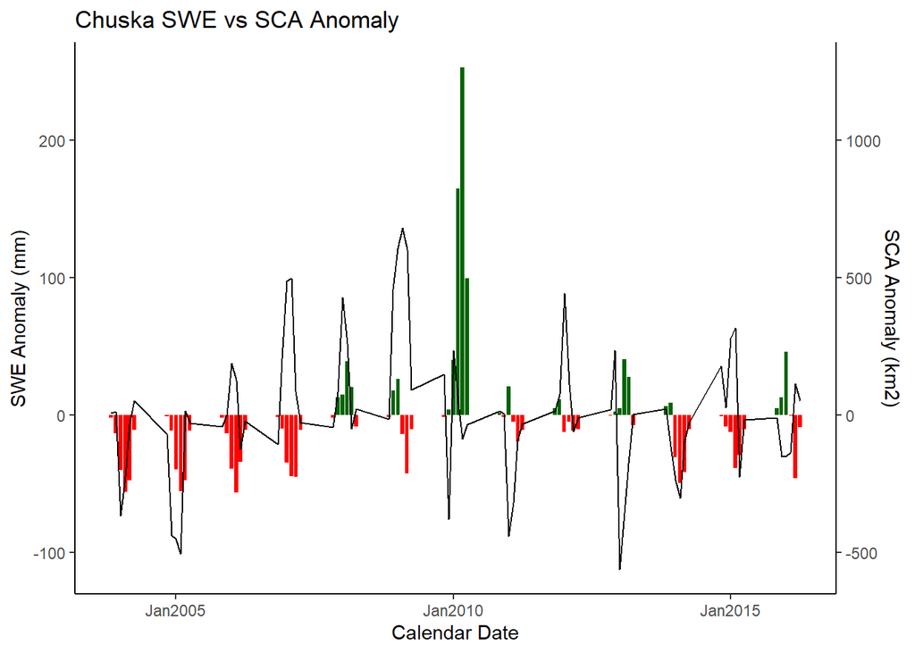

- SCA anomalies only somewhat track to SWE anomalies